# 4. Occupation Trends of Top Occupations

Clinton

5 March 2020

```
Objective: To visualise how the occupations have changed across the three time periods of 1850, 1880 and 1910.

The graphing process showed that there were some inconsistencies with the coding of `occstr`, such as "DRESSMAKER" and "DRESS MAKER" which need to be addressed.
```

### 1. Set Up

#### 1850

```r
library(dplyr)
library(ggplot2)
library(treemap)
library(extrafont)
library(stringr)
loadfonts()
library(knitr)
library(kableExtra)
library(tidyr)

# Loading
mn_1850 = readr::read_csv("../Data/census_1850_occ_mn.csv") %>% mutate(city = "Manhattan")
bk_1850 = readr::read_csv("../Data/census_1850_occ_bk.csv") %>% mutate(city = "Brooklyn")
OCC_1880 = readr::read_csv("../Data/OCC1880.csv")

# Combining Data
combined_1850 = rbind(mn_1850, bk_1850) %>%
  select(age, sex, marst, race, labforce,
         occ, city, everything()) %>%
  left_join(OCC_1880, by = c("occ" = "code")) %>%
  mutate(race = factor(race,
                       levels = c(100,120,200,210,300),
                       labels = c("White", "Black (white)",
                                  "Black / African American",
                                  "Mulatto", "American Indian")),
         labforce = factor(labforce,
                           levels = c(0,1,2),
                           labels = c("N/A",
                                      "No, not in the labor force",
                                      "Yes, in the labor force")),
         sex = factor(sex,
                      levels = c(1,2),
                      labels = c("Male", "Female")),
         marst = factor(marst,
                        levels = c(1:6),
                        labels = c("Married, spouse present",
                                   "Married, spouse absent",
                                   "Separated",
                                   "Divorced",
                                   "Widowed",
                                   "Never married/single")))

# Theme setting for visualisations
theme_set(theme_minimal() +
            theme(panel.grid.minor = element_blank(),
                  text = element_text(family = "Quicksand",
                                      colour = "black")))
col_sex = c("#e21737", "#0b648f")
col_miss = c("#86b817", "#e53238")

# Saving Memory
rm(OCC_1880)
rm(bk_1850)
rm(mn_1850)
```

#### 1880

```r
# Loading
mn_1880 = readr::read_csv("../Data/census_1880_occ_mn.csv") %>% mutate(city = "Manhattan")
bk_1880 = readr::read_csv("../Data/census_1880_occ_bk.csv") %>% mutate(city = "Brooklyn")
OCC_1880 = readr::read_csv("../Data/OCC1880.csv")

# Combining Data
combined_1880 = rbind(mn_1880, bk_1880) %>%
  select(age, sex, race, labforce,
         occ, city, everything()) %>%
  left_join(OCC_1880, by = c("occ" = "code")) %>%
  mutate(age = ifelse(age == "Less than 1 year old",
                      0,
                      age),
         age = as.numeric(age))

rm(OCC_1880)
rm(bk_1880)
rm(mn_1880)
```

#### 1910

```r
# Loading
mn_1910 = readr::read_csv("../Data/census_1910_occ_mn.csv") %>% mutate(city = "Manhattan")
bk_1910 = readr::read_csv("../Data/census_1910_occ_bk.csv") %>% mutate(city = "Brooklyn")
OCC_1950 = readr::read_csv("../Data/OCC1950.csv")

# Combining Data
combined_1910 = rbind(mn_1910, bk_1910) %>%
  left_join(OCC_1950, by = c("occ1950" = "code")) %>%
  mutate(sex = factor(sex,
                      levels = c(1,2),
                      labels = c("Male", "Female")),
         labor_force = factor(labor_force,
                              levels = c(0,1,2),
                              labels = c("N/A",
                                         "No, not in the labor force",
                                         "Yes, in the labor force")))

rm(OCC_1950)
rm(mn_1910)
rm(bk_1910)
```

### 2. Analysis of Occupation Trends

#### README

This section investigated how occupations have changed across the three time periods of 1850, 1880 and 1910. To this end, `occstr` was preferred over `label` due to the consistent categorising of occupations.

Again, as with the previous section of Occupation counts by year, the only respondents who were in the “Yes, in the labor force” level of `labforce` were included.

Specifically, the following tabs investigate the top 10 occupations of each time period, and a list of them is shown in the next tab.

#### Top 10 Jobs of each year, across time

The tabe below shows the top 10 jobs in each time period

```r
top10_1850 = combined_1850 %>%
  filter(labforce == "Yes, in the labor force") %>%
  count(occstr) %>%
  arrange(desc(n)) %>%
  .[1:10, "occstr"]

top10_1880 = combined_1880 %>%
  filter(labforce == "Yes, in the labor force") %>%
  count(occstr) %>%
  arrange(desc(n)) %>%
  .[1:10, "occstr"]

top10_1910 = combined_1910 %>%
  filter(labor_force == "Yes, in the labor force" &
           !is.na(occstr)) %>%
  count(occstr) %>%
  arrange(desc(n)) %>%
  .[1:10, "occstr"]

cbind(top10_1850, top10_1880, top10_1910) %>%
  kable(col.names = c("1850", "1880", "1910")) %>%
  kable_styling() %>%
  scroll_box(width = "100%", height = "300px")
```

| 1850 | 1880 | 1910 |
| --- | --- | --- |
| LABORER | LABORER | LABORER |
| CLERK | SERVANT | CLERK |
| TAILOR | CLERK IN STORE | OPERATOR |
| CARPENTER | TAILOR | SALESMAN |
| MERCHANT | CARPENTER | SERVANT |
| SEAMAN | CLERK | TAILOR |
| GROCER | DRESS MAKER | DRIVER |
| MASON | BUTCHER | DRESSMAKER |
| SHOEMAKER | PAINTER | CARPENTER |
| CARTMAN | DRESSMAKER | STENOGRAPHER |

- From the table of top 10 occupations, we can see that aside from the top jobs being laborers and clerks, there is an inconsistency with the coding of `occstr`in 1880, such as “DRESSMAKER” and “DRESS MAKER”.
- Subsequently, the code was re-ran, to count Dress Maker and Dressmaker together, along with Clerk and Clerk in store. On this run, further ammendments were added, such as to add Domestic Servant and Servant together. The code is not shown, but the new results are:

| 1850 | 1880 | 1910 |
| --- | --- | --- |
| LABORER | SERVANT | LABORER |
| CLERK | LABORER | CLERK |
| TAILOR | CLERK | OPERATOR |
| CARPENTER | DRESSMAKER | SALESMAN |
| MERCHANT | TAILOR | SERVANT |
| SEAMAN | CARPENTER | TAILOR |
| GROCER | BUTCHER | DRIVER |
| MASON | PAINTER | DRESSMAKER |
| SHOEMAKER | PRINTER | CARPENTER |
| CARTMAN | CIGAR MAKER | STENOGRAPHER |

#### Table of Top Occupations

```r
top10_combined = top10_years %>%
  left_join(combined_1850 %>%
              filter(occstr %in% top10_years$occstr) %>%
              count(occstr),
            by = "occstr") %>%
  left_join(combined_1880 %>%
              filter(occstr %in% top10_years$occstr) %>%
              count(occstr),
            by = "occstr") %>%
  left_join(combined_1910 %>%
              filter(occstr %in% top10_years$occstr) %>%
              count(occstr),
            by = "occstr") %>%
  select(occupation = occstr,
         t_1850 = n.x,
         t_1880 = n.y,
         t_1910 = n) %>%
  gather(key = "year", value = "count", -occupation) %>%
  mutate(year = case_when(year == "t_1850" ~ 1850,
                          year == "t_1880" ~ 1880,
                          year == "t_1910" ~ 1910),
         count = ifelse(is.na(count),
                        0,
                        count))

# Adding logical of if occupation was a top 10 for that particular year
top10_by_year = rbind(cbind(top10_1850, year = 1850),
        cbind(top10_1880, year = 1880),
        cbind(top10_1910, year = 1910)) %>%
  select(occupation = occstr, year) %>%
  mutate(top = 1)

top10_combined = top10_combined %>%
  left_join(top10_by_year, by = c("occupation", "year")) %>% mutate(top = ifelse(is.na(top),
                                                                                 0,
                                                                                 1))

top10_combined %>%
  select(occupation, year, top) %>%
  spread(key = year, value = top)%>%
  kable(col.names = c("occupation","1850", "1880", "1910")) %>%
  kable_styling() %>%
  scroll_box(width = "100%", height = "300px")
```

| occupation | 1850 | 1880 | 1910 |
| --- | --- | --- | --- |
| BUTCHER | 0 | 1 | 0 |
| CARPENTER | 1 | 1 | 1 |
| CARTMAN | 1 | 0 | 0 |
| CIGAR MAKER | 0 | 1 | 0 |
| CLERK | 1 | 1 | 1 |
| DRESSMAKER | 0 | 1 | 1 |
| DRIVER | 0 | 0 | 1 |
| GROCER | 1 | 0 | 0 |
| LABORER | 1 | 1 | 1 |
| MASON | 1 | 0 | 0 |
| MERCHANT | 1 | 0 | 0 |
| OPERATOR | 0 | 0 | 1 |
| PAINTER | 0 | 1 | 0 |
| PRINTER | 0 | 1 | 0 |
| SALESMAN | 0 | 0 | 1 |
| SEAMAN | 1 | 0 | 0 |
| SERVANT | 0 | 1 | 1 |
| SHOEMAKER | 1 | 0 | 0 |
| STENOGRAPHER | 0 | 0 | 1 |
| TAILOR | 1 | 1 | 1 |

- The table above indicates 1 if the occupation was a top 10 occupation in that time period, and 0 otherwise.
- It shows that some occupations became only popular in later time periods, such as “DRIVER”, while other occupations were only popular in earlier time periods such as “GROCER”.

#### Changes in Top 10 Occupations (Dot Plot)

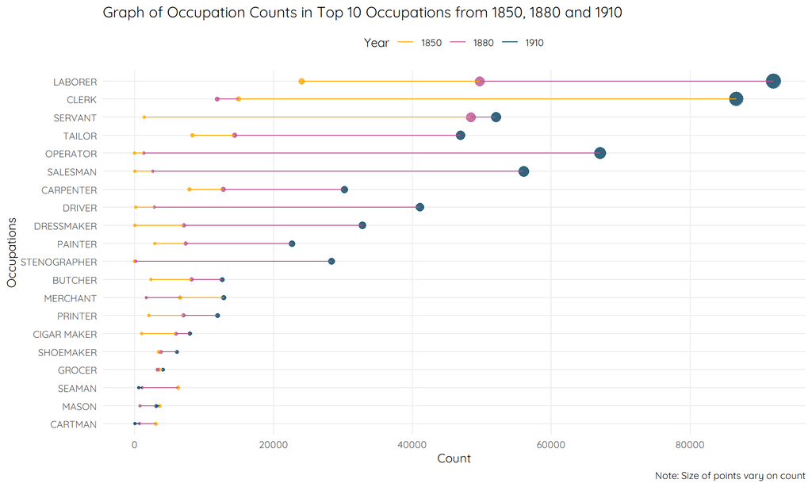

```r
col_3 = c("#ffa600", "#bc5090", "#003f5c")
top10_combined %>%
  ggplot(aes(y = reorder(occupation, count),
             x = count,
             col = factor(year),
             group = occupation)) +
  geom_point(aes(size = count),
             alpha = 0.8,
             show.legend = FALSE) +
  geom_line() +
  scale_color_manual(values = col_3) +
  scale_radius() +
  scale_x_continuous(breaks = seq(0, 100000, 20000)) +
  labs(y = "Occupations", col = "Year", x = "Count",
       title = "Graph of Occupation Counts in Top 10 Occupations from 1850, 1880 and 1910",
       caption = "Note: Size of points vary on count") +
  theme(legend.position = "top")
```

- From the graph, we can see that laborer,and clerks were top occupations in 1910.
- Some occupations were top 10, but saw little change such as grocers, masons and cartmen.
- This also highlights a need to check for the coding of “Clerk” in 1880, as it might be a mistake in the categorising of a clerk, given that the count had dropped in 1880l, but increased greatly in 1910.

#### Changes in Top 10 Occupations (Line Graph)

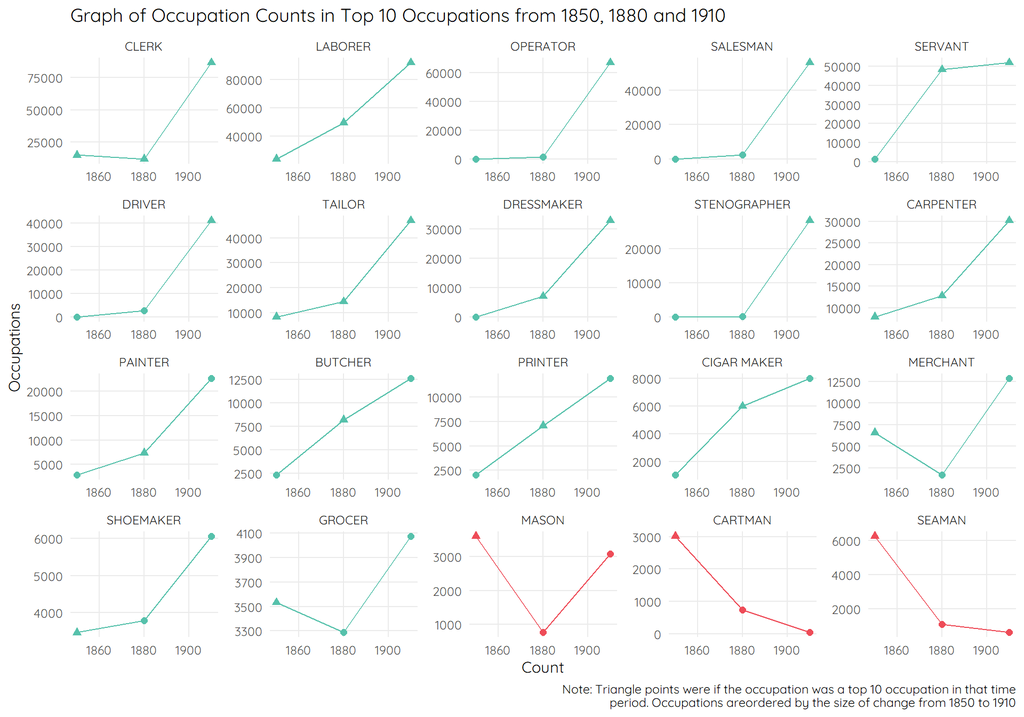

```r
top10_combined %>%
  group_by(occupation) %>%
  mutate(difference = first(count) - last(count),
         colour = ifelse(difference > 0,
                         "#86b817",
                         "#e53238")) %>%
  ggplot(aes(y = count, x = year)) +
  geom_point(aes(col = colour,
                 shape = factor(top)),
             size = 2) +
  geom_line(aes(col = colour)) +
  facet_wrap(~reorder(occupation, difference),
             scales = "free") +
  scale_colour_manual(values = c("#ee4c58", "#56c1ab")) +
  labs(y = "Occupations", col = "Year", x = "Count",
       title = "Graph of Occupation Counts in Top 10 Occupations from 1850, 1880 and 1910",
       caption = "Note: Triangle points were if the occupation was a top 10 occupation in that time\nperiod. Occupations areordered by the size of change from 1850 to 1910") +
  theme(legend.position = "none")
```

#### Changes in Top 10 Occupations (Bar Graph)

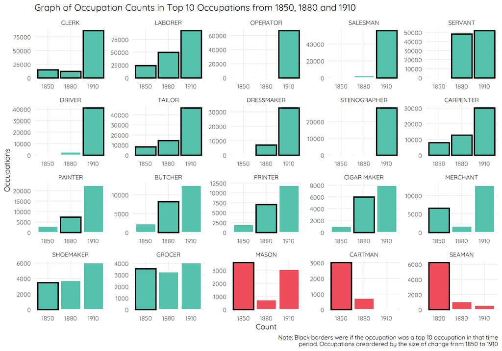

```r
top10_combined %>%
  group_by(occupation) %>%
  mutate(difference = first(count) - last(count),
         colour = ifelse(difference > 0,
                         "#86b817",
                         "#e53238")) %>%
  ggplot(aes(y = count, x = year)) +
  geom_col(aes(fill = colour,
               col = factor(top)),
           size = 1) +
  facet_wrap(~reorder(occupation, difference),
             scales = "free") +

  scale_color_manual(values = c("white", "black")) +
  scale_fill_manual(values = c("#ee4c58", "#56c1ab")) +
  scale_x_continuous(breaks = c(1850, 1880, 1910)) +

  labs(y = "Occupations", col = "Year", x = "Count",
       title = "Graph of Occupation Counts in Top 10 Occupations from 1850, 1880 and 1910",
       caption = "Note: Black borders were if the occupation was a top 10 occupation in that time\nperiod. Occupations areordered by the size of change from 1850 to 1910") +
  theme(legend.position = "none")
```